# Methods for Data Science Coursework 2

Juliette Limozin  
CID: 01343907  
Due: 02/12/2019, 4 pm

## Preliminaries

```python
import numpy as np
import pandas as pd
import matplotlib as mpl
import matplotlib.pyplot as plt
%matplotlib inline

import time

train = pd.read_csv("train_set.csv")
test = pd.read_csv("test_set(1).csv")
```

```python
train.head()
```

|  | Unnamed: 0 | buying | maint | doors | persons | lug_boot | safety | rating |
| --- | --- | --- | --- | --- | --- | --- | --- | --- |
| 0 | 0 | low | med | 3 | 4 | small | high | good |
| 1 | 0 | vhigh | vhigh | 2 | 2 | small | low | good |
| 2 | 0 | med | med | 5more | 4 | med | high | good |
| 3 | 0 | low | med | 3 | 4 | small | high | unacc |
| 4 | 0 | vhigh | vhigh | 2 | 2 | small | low | unacc |

```python
test.head()
```

|  | Unnamed: 0 | buying | maint | doors | persons | lug_boot | safety | rating |
| --- | --- | --- | --- | --- | --- | --- | --- | --- |
| 0 | 0 | med | low | 3 | 4 | small | med | acc |
| 1 | 1 | low | low | 2 | more | big | med | good |
| 2 | 1 | vhigh | vhigh | 2 | 2 | small | med | good |
| 3 | 1 | low | low | 2 | more | big | med | unacc |
| 4 | 1 | vhigh | vhigh | 2 | 2 | small | med | unacc |

```python
train = train.drop(train.columns[0], axis = 1)
train = train.dropna()
train = train.reset_index(drop=True)

test = test.drop(test.columns[0], axis = 1)
test = test.dropna()
test = test.reset_index(drop=True)
```

```python
train = train.replace(['low', 'med', 'high', 'vhigh',
                       '2', '3', '4', '5more', 'more',
                       'small', 'big',
                       'unacc', 'acc', 'good', 'vgood'],
                      [0, 1, 2, 3,
                      0, 1, 2, 3, 3,
                      0, 2,
                      0, 1, 2, 3])

test = test.replace(['low', 'med', 'high', 'vhigh',
                       '2', '3', '4', '5more', 'more',
                       'small', 'big',
                       'unacc', 'acc', 'good', 'vgood'],
                      [0, 1, 2, 3,
                      0, 1, 2, 3, 3,
                      0, 2,
                      0, 1, 2, 3])
```

```python
train.head()
```

|  | buying | maint | doors | persons | lug_boot | safety | rating |
| --- | --- | --- | --- | --- | --- | --- | --- |
| 0 | 0 | 1 | 1 | 2 | 0 | 2 | 2 |
| 1 | 3 | 3 | 0 | 0 | 0 | 0 | 2 |
| 2 | 1 | 1 | 3 | 2 | 1 | 2 | 2 |
| 3 | 0 | 1 | 1 | 2 | 0 | 2 | 0 |
| 4 | 3 | 3 | 0 | 0 | 0 | 0 | 0 |

```python
test.head()
```

|  | buying | maint | doors | persons | lug_boot | safety | rating |
| --- | --- | --- | --- | --- | --- | --- | --- |
| 0 | 1 | 0 | 1 | 2 | 0 | 1 | 1 |
| 1 | 0 | 0 | 0 | 3 | 2 | 1 | 2 |
| 2 | 3 | 3 | 0 | 0 | 0 | 1 | 2 |
| 3 | 0 | 0 | 0 | 3 | 2 | 1 | 0 |
| 4 | 3 | 3 | 0 | 0 | 0 | 1 | 0 |

```python
from sklearn.preprocessing import StandardScaler
sc = StandardScaler()

train[['buying', 'maint', 'doors', 'persons', 'lug_boot', 'safety']] = pd.DataFrame(sc.fit_transform(train[['buying', 'maint', 'doors', 'persons', 'lug_boot', 'safety']]))
test[['buying', 'maint', 'doors', 'persons', 'lug_boot', 'safety']] = pd.DataFrame(sc.transform(test[['buying', 'maint', 'doors', 'persons', 'lug_boot', 'safety']]))
```

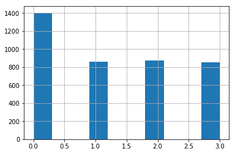

```python
zero = train[train.rating == 0]
one = train[train.rating == 1]
two = train[train.rating == 2]
three = train[train.rating == 3]

train.rating.hist()
```

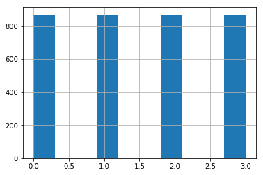

```python
count_two = len(two)
zero_under = zero.sample(count_two)
one_under = one.sample(count_two, replace=True)
two_under = two.sample(count_two)
three_under = three.sample(count_two, replace=True)

train = pd.concat([zero_under, one_under, two_under, three_under], axis=0)

train.rating.hist()
```

## Task 1

Throughout the coursework, ATOW will mean "at time of writing".

In this part we will use the **GridSearchCV** function to optimise and train a Random Forest Classifier.

First, we prepare the data by creating a matrix X of descriptors and a vector y of the ratings for both the training and test data sets.

```python
X_train = train[['buying', 'maint', 'doors', 'persons', 'lug_boot', 'safety']]
y_train = train['rating']

X_test = test[['buying', 'maint', 'doors', 'persons', 'lug_boot', 'safety']]
y_test = test['rating']
```

Next, we import the relevant functions for this task and start the Grid Search cross validation.

The reason why I chose GridSearchCV for my parameter tuning is that it is a useful "all-one-in" function: it directly fits the model I want to optimise with the best parameters it has found, and can predict the ratings of my test data using .predict(X_test). I also gives me quite an exhaustive confusion matrix which allows be to look at the performance of the search in details.

First I decided to train and test a Random Forest Classifier with its default hyperparameters.

```python
# Import relevant functions
from sklearn.ensemble import RandomForestClassifier
from sklearn.model_selection import StratifiedKFold
from sklearn.model_selection import GridSearchCV
from sklearn.metrics import accuracy_score

#Train and test a default Random Forest Classifier
forest = RandomForestClassifier(random_state = 1)
modelF = forest.fit(X_train, y_train)
y_predF = modelF.predict(X_test)

print('Accuracy on the test data: {0:.3f}%'.format( 100* accuracy_score(y_test, y_predF)))
```

```
Accuracy on the test data: 48.286%
```

As you can see, we get an accuracy at predicting the test data of about 50% ATOW.

Now let us do the parameter tuning:

```python
# Define the Cross Validation method as the stratified 5-fold cross validation
skf = StratifiedKFold(n_splits=5, shuffle = True, random_state = 999)

#Fit it to the train set
cv=skf.split(X_train, y_train)

# Choose the values of the number of decision trees, their depth and
# the maximum number of descriptors (features) randomly chosen at each split that I want to test out with GridSearchCV
n_estimators = np.arange(200,1000, 100)
max_depth = np.arange(10,30,5)
max_features = [1,2,3,4,5,6]

# I summarise these values into a grid
hyperF = dict(n_estimators = n_estimators, max_depth = max_depth,
              max_features = max_features)

# Set GridSearch CV with model to tune as RFC, grid of hyperparameters, cross validation method as
# stratified K fold, and the scoring method as the  the accuracy of your validation predictions
gridF = GridSearchCV(RandomForestClassifier(), hyperF, cv = cv, scoring = 'accuracy', verbose = 1,
                      n_jobs = -1)

# Fit the model with the train set
gridF.fit(X_train, y_train)

#Define the prediction on the test set for Task 4
y_predF = gridF.predict(X_test)
```

```
Fitting 5 folds for each of 192 candidates, totalling 960 fits
```

```
[Parallel(n_jobs=-1)]: Using backend LokyBackend with 4 concurrent workers.
[Parallel(n_jobs=-1)]: Done  42 tasks      | elapsed:   44.5s
[Parallel(n_jobs=-1)]: Done 192 tasks      | elapsed:  2.8min
[Parallel(n_jobs=-1)]: Done 442 tasks      | elapsed:  6.9min
[Parallel(n_jobs=-1)]: Done 792 tasks      | elapsed: 12.1min
[Parallel(n_jobs=-1)]: Done 960 out of 960 | elapsed: 15.0min finished
```

```python
print('Best hyperparameters found by grid search:', gridF.best_params_)
print()
print('Average accuracy of validation predictions in the cross validation using the best hyperparameters: {0:.3f}%'
      .format( 100* gridF.best_score_))
print()
print("Accuracy of optimised model's prediction on the test set: {0:.3f}%"
      .format( 100* accuracy_score(y_test, y_predF)))
```

```
Best hyperparameters found by grid search: {'max_depth': 10, 'max_features': 3, 'n_estimators': 700}

Average accuracy of validation predictions in the cross validation using the best hyperparameters: 34.300%

Accuracy of optimised model's prediction on the test set: 51.210%
```

As we can see, the accuracy of the prediction of the test data is improved thanks to this optimisation of the hyperparameters.

However **my best parameters depend highly on the hyperparameter grid I defined (hyperF)**. Ideally we would test as many possible values of each hyperparameter as possible but an ordinary laptop like mine isn't capable to run such an ehaustive search.

Now let us look at which of these three hyperparameter had the biggest impact on performance.

GridSearchCV gives the mean (as in average over the 5 folds) validation score for each combination of values of the hyperparameters. I summarise these findings:

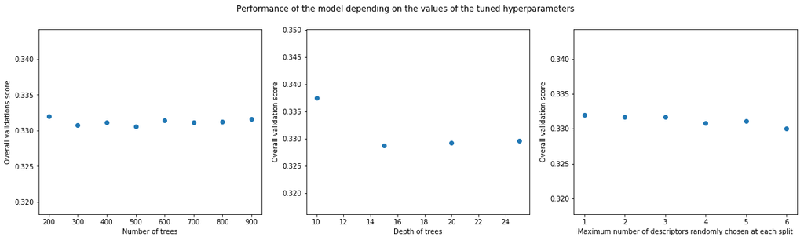

|  | Variance of validation scores |
| --- | --- |
| Number of trees | 2.04234e-07 |
| Depth of trees | 1.77922e-05 |
| Maximum number of descriptors randomly chosen at each split | 5.37235e-07 |

```python
# Define the cross validation results dataframe
RF_results = pd.DataFrame(gridF.cv_results_)

#Create a dataframe of parameters values and the corresponding average mean validation scores at the cross validation
#for each hyperparameter
n_set = pd.DataFrame(RF_results.groupby(['param_n_estimators'], group_keys=False).mean_test_score.mean())
depth_set = pd.DataFrame(RF_results.groupby(['param_max_depth'], group_keys=False).mean_test_score.mean())
descriptors_set = pd.DataFrame(RF_results.groupby(['param_max_features'], group_keys=False).mean_test_score.mean())

# Reset the index
n_set.reset_index(level=0, inplace=True)
depth_set.reset_index(level=0, inplace=True)
descriptors_set.reset_index(level=0, inplace=True)

#Plot validation score vs parameter value
fig, (ax1, ax2, ax3) = plt.subplots(1,3, figsize = (20, 5))

# Set labels
ax1.set_xlabel('Number of trees')
ax2.set_xlabel('Depth of trees')
ax3.set_xlabel('Maximum number of descriptors randomly chosen at each split')
ax1.set_ylabel('Overall validations score')
ax2.set_ylabel('Overall validation score')
ax3.set_ylabel('Overall validation score')

# Plot along corresponding x axis
ax1.scatter(n_set.param_n_estimators, n_set.mean_test_score)
ax2.scatter(depth_set.param_max_depth, depth_set.mean_test_score)
ax3.scatter(descriptors_set.param_max_features, descriptors_set.mean_test_score)

# Create title
fig.suptitle('Performance of the model depending on the values of the tuned hyperparameters')

# Show the plot
plt.show()

#Create table that will contain the variances
variances = pd.DataFrame([]*3, columns = ['Variance of validation scores'],
                         index = ['Number of trees', 'Depth of trees', 'Maximum number of descriptors randomly chosen at each split'] )

#Calculate variances
variances.iloc[0,0] = n_set.mean_test_score.var()
variances.iloc[1,0] = depth_set.mean_test_score.var()
variances.iloc[2,0] = descriptors_set.mean_test_score.var()

#Show table of variances
variances
```

It is clear not only from the plots but from the table of variance of the validation scores that the **depth of trees seems to be the hyperparameter that has the biggest impact on the performance of the model**, followed by the number of descriptors randomly chosen then the number of trees.

The mathematical explanation as to why depth has such an impact is that the deeper the tree, the better the performance on the training set which can result in overfitting, which causes the test set performance to decrease. in other words, the deeper the trees the lower the bias at the expense of a higher variance.

## Task 2

For this task, I used the same method as task 1 to tune the hyperparameters of a support vector machine. My hyperparameters are the kernel with options linear, polynomial and rbf as asked in the task, and three more hyperparameters that I chose to tune: **C**, the penalty parameter of the error term, **gamma**, the kernel coefficient for rbf and polynomial kernels and **degree**, the degree of the polynomial kernel function.

I chose those hyperparameters specifically as they seem to be the most useful parameters to tune in a support vector machine from what I understood in my research.

We proceed with the same steps as in task 1:

```python
#Import relevant function
from sklearn.svm import SVC

# Redefine the cross validation method
skf = StratifiedKFold(n_splits=5, shuffle = True, random_state = 999)
cv=skf.split(X_train, y_train)

#Define the grid of hyperparameter values
tuned_params = [{'kernel': ['rbf'], 'gamma': [1e-3, 1e-4, 1e-5],
                     'C': [1, 10, 100, 1000]},
                    {'kernel': ['linear'], 'C': [1, 10, 100, 1000]},
                    {'kernel': ['poly'], 'gamma': [1e-3, 1e-4, 1e-5], 'degree': [0, 1, 2, 3, 4, 5, 6],
                     'C': [1, 10, 100, 1000]}]

#Set GridSearchCV with model to tune as support vector machine
gridSVM = GridSearchCV(SVC(), tuned_params, cv = cv, scoring='accuracy', verbose = 1, n_jobs = -1)

#Fit the search with the training data set
gridSVM.fit(X_train, y_train)

y_predSVM = gridSVM.predict(X_test)
```

```
Fitting 5 folds for each of 100 candidates, totalling 500 fits
```

```
[Parallel(n_jobs=-1)]: Using backend LokyBackend with 4 concurrent workers.
[Parallel(n_jobs=-1)]: Done  42 tasks      | elapsed:   13.8s
[Parallel(n_jobs=-1)]: Done 192 tasks      | elapsed:  5.0min
[Parallel(n_jobs=-1)]: Done 442 tasks      | elapsed:  5.9min
[Parallel(n_jobs=-1)]: Done 500 out of 500 | elapsed:  6.3min finished
```

```python
print('Best parameters found by grid search:', gridSVM.best_params_)
print()
print('Average accuracy of validation predictions using the best hyperparameters: {0:.3f}%'
      .format(100* gridSVM.best_score_))
print()
print("Accuracy of optimised model's prediction on test set: {0:.3f}%"
      .format(100* accuracy_score(y_test, y_predSVM)))
```

```
Best parameters found by grid search: {'C': 1000, 'gamma': 0.001, 'kernel': 'rbf'}

Average accuracy of validation predictions using the best hyperparameters: 35.218%

Accuracy of optimised model's prediction on test set: 54.032%
```

So the best SVM has **rbf** kernel function and parameters **C = 1000 and gamma = 0.001**.

It makes sense that the rbf kernel function was chosen as the best one as we are dealing with a large, linearly unseparable data set, hence it being more appropriate than the linear or polynomial kernels. The latter is more appropriate for natural language processing, which is not the task here.

Again, it is worth mentioning that my result highly depends on the range of hyperparameter values I tested on.

C being chosen as a high value also makes sense as it is a parameter that deals with correcting overfitting; because the training set is large, it is more prone to overfit when running the SVM, hence the high value of C to avoid errors on new data.

## Task 3

For this task, we would like to train a neural network to classify each car in the training set based on the six descriptors using Pytorch. I can't proceed in the same way as the two previous tasks as there isn't a neat modelling function like RandomForestClassifier or SVC where we just need to input hyperparameters to train and test a Neural Network. We have to create the steps manually here.

So instead I proceed with creating a function that trains and tests a feed-forward neural network, and plots the training loss as well as predict the test set.

It's worth noting that my code is heavily based on the example given in lectures.

First I import the necessary package and functions:

```python
# Import relevant package and functions
import torch
import torch.nn as nn
import torch.utils.data
import torch.nn.functional as F
```

Next, I define the parameters of the set-up of the network:

```python
# Define network set-up
input_size = 6
hidden_size = 200
num_classes = 4
num_epochs = 120
batch_size = 64
learning_rate = 0.01
```

I then prepare the data set for PyTorch.

```python
# Prepare data
X_train_nn = torch.from_numpy(X_train.values).float()
y_train_nn = torch.from_numpy(np.array(y_train))
X_test_nn = torch.from_numpy(X_test.values).float()
y_test_nn = torch.from_numpy(np.array(y_test))
```

Next, I define a function (mostly for simplicity as I will need to run the neural network several times later on to test the different set-ups) that takes in the prepared data and the set-up parameters, and returns a trained neural network with a graph of the training loss and the accuracy on the prediction of the test set.

Note that I did the data preparation just above **outside** of the function so that we are working with the same prepared data for all set-ups of the neural network we will test throughout this task.

```python
def NeuralNet_function(X_train_nn, y_train_nn, X_test_nn, y_test_nn,
                       input_size, hidden_size, num_classes,num_epochs, batch_size, learning_rate):


    # Define a tensor data set and data loader as this is a requirement for PyTorch:
    # The tensor data set converts the data into a tensor and the data loader slices
    # the data into batches, which are feeded into the neural network one after another.
    train_nn = torch.utils.data.TensorDataset(X_train_nn, y_train_nn)
    train_loader = torch.utils.data.DataLoader(train_nn, batch_size=batch_size)

    test_nn = torch.utils.data.TensorDataset(X_test_nn, y_test_nn)
    test_loader = torch.utils.data.DataLoader(test_nn, batch_size=batch_size)

    # Define a fully connected neural network with two hidden layers, using ReLU as my activation function
    class NeuralNet(nn.Module):
        def __init__(self, input_size, hidden_size, num_classes):
            super(NeuralNet, self).__init__()
            self.fc1 = nn.Linear(input_size, hidden_size)
            self.fc2 = nn.Linear(hidden_size, hidden_size)
            self.fc3 = nn.Linear(hidden_size, num_classes)
        def forward(self, x):
            out = F.relu(self.fc1(x))
            out = F.relu(self.fc2(out))
            out = self.fc3(out)

            return out

    # Name the neural network
    net = NeuralNet(input_size, hidden_size, num_classes)

    # Define the loss function as cross-entropy
    criterion = nn.CrossEntropyLoss()

    # Fix the optimisation method to be stochastic gradient descent
    optimiser = torch.optim.SGD(net.parameters(), lr=learning_rate)

    total_step = len(train_loader)
    loss_values = []

    #Start timer of the training
    start_time = time.time()
    for epoch in range(num_epochs+1):

      #TRAIN MODEL
      net.train()
      train_loss = 0.0

      for i, (inputs, labels) in enumerate(train_loader, 0):
        labels = labels

        # forward pass
        outputs = net(inputs)
        loss = criterion(outputs, labels)

        # backward and optimise
        optimiser.zero_grad()
        loss.backward()
        optimiser.step()

        # update loss
        train_loss += loss.item()

      loss_values.append(train_loss / total_step)

    print('Finished Training')
    elapsed_time = int(time.time() - start_time)
    print('Time it took to train model: {:02d}min {:02d}sec'.format((elapsed_time % 3600 // 60), elapsed_time % 60))

    plt.figure(figsize=(12,8))
    plt.xlim(-1, num_epochs+1)
    plt.ylabel('Training Loss', fontsize=20)
    plt.xlabel('Epoch', fontsize=20)
    plt.plot(loss_values)

    plt.show()

    # TEST MODEL
    net.eval()

    correct = 0
    total = 0
    y_predNN = []
    for inputs, labels in test_loader:
      outputs = net(inputs)
      _, predicted = torch.max(outputs.data, 1)
      y_predNN.append(predicted.numpy())
      total += labels.size(0)
      correct += (predicted == labels).sum().item()

    y_predNN = np.concatenate(y_predNN)

    print('Accuracy of the network on the test set: {0:.3f} %'.format(100 * correct / total))
```

Now that we have defined this useful function, we can train the Neural Network and get an insight on its convergence and performance:

```
Finished Training
Time it took to train model: 00min 29sec
```

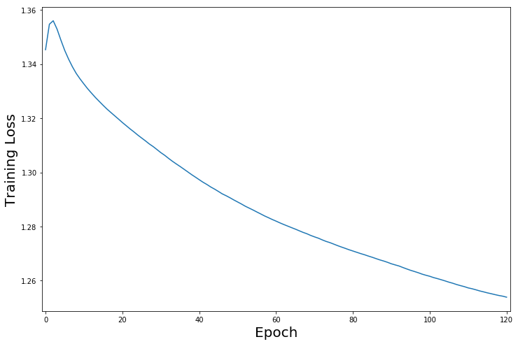

```
Accuracy of the network on the test set: 41.835 %
```

```python
NeuralNet_function(X_train_nn, y_train_nn, X_test_nn, y_test_nn, input_size, hidden_size, num_classes,num_epochs, batch_size, learning_rate)
```

Now let us look at how differet set-ups of the network change convergence and performance.

### 3.1

Stochastic gradient descent is an optimization algorithm that estimates the error gradient for the current state of the model using examples from the training dataset, then updates the weights of the model using backpropagation.

The amount that the weights are updated during training is referred to as the learning rate.

The learning rate defines how quickly the model is adapted to the problem, and ranges between 0 and 1.

Let us first look at a set-up where the learning rate is set to 0.0005, a very small value. We use my function again by changing the value of learning_rate.

```
Finished Training
Time it took to train model: 00min 25sec
```

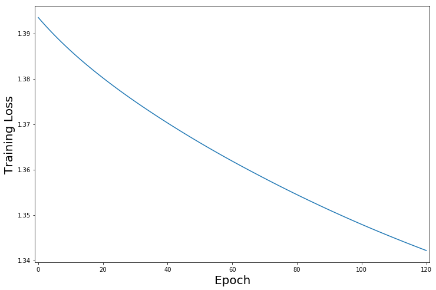

```
Accuracy of the network on the test set: 49.698 %
```

```python
NeuralNet_function(X_train_nn, y_train_nn, X_test_nn, y_test_nn,
                   input_size, hidden_size, num_classes, num_epochs, batch_size, learning_rate = 0.0005)
```

Now let us look at the opposite scenario where the learning rate is very large, at 0.95.

```
Finished Training
Time it took to train model: 00min 28sec
```

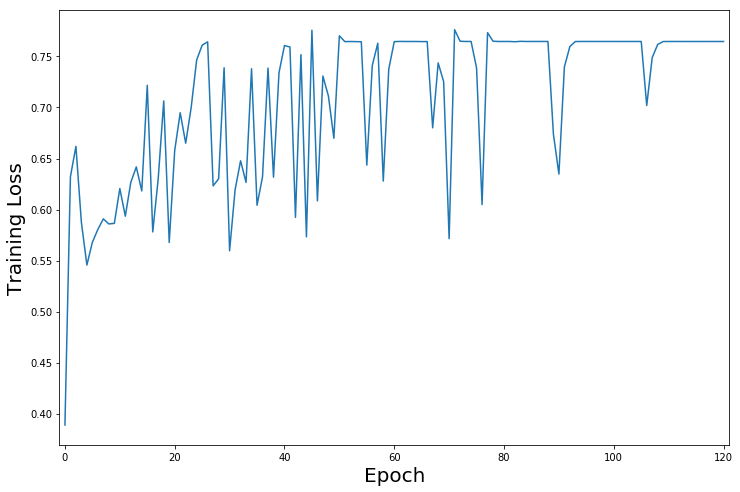

```
Accuracy of the network on the test set: 18.952 %
```

```python
NeuralNet_function(X_train_nn, y_train_nn, X_test_nn, y_test_nn,
                   input_size, hidden_size, num_classes, num_epochs, batch_size, learning_rate = 0.95)
```

Now, the training loss is acting chaotic with no convergence, and even the accuracy is heavily affected.

Here is the mathematical explanation to both these results.

Smaller learning rates require more training epochs given the smaller changes made to the weights at each update, whereas larger learning rates result in rapid changes and require fewer training epochs.

If the larning ate is too large, it causes the model to converge too quickly to a solution that is suboptimal, whereas a learning rate that is too small can cause the process to get stuck.

### 3.2

Now let us look at the importance of batch size.

Batch size controls the accuracy of the estimate of the error gradient when training neural networks. Let's look at a set-up where the batch size is extremely small, set at 2.

```python
# Sense-checking that learning rate is back to 0.01
learning_rate
```

```
0.01
```

```
Finished Training
Time it took to train model: 04min 48sec
```

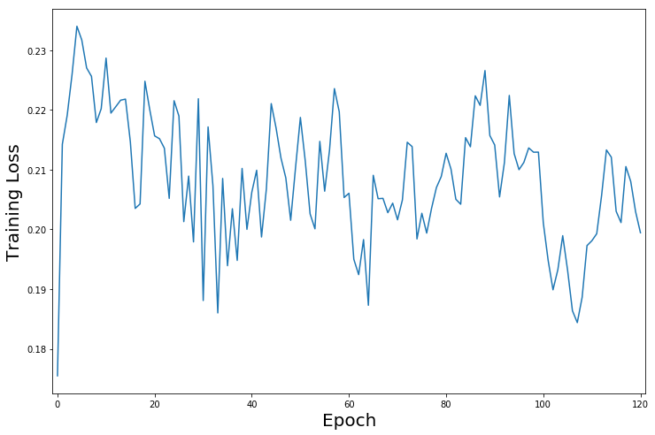

```
Accuracy of the network on the test set: 19.556 %
```

```python
NeuralNet_function(X_train_nn, y_train_nn, X_test_nn, y_test_nn,
                   input_size, hidden_size, num_classes, num_epochs, 2, learning_rate)
```

Again, the training loss is very chaotic, accuracy is lower again and the computational cost is very high as this took 5 min to run as opposed to 25 seconds with the original batch size.

Now let's look at a set-up with a large batch size, of 256:

```
Finished Training
Time it took to train model: 00min 17sec
```

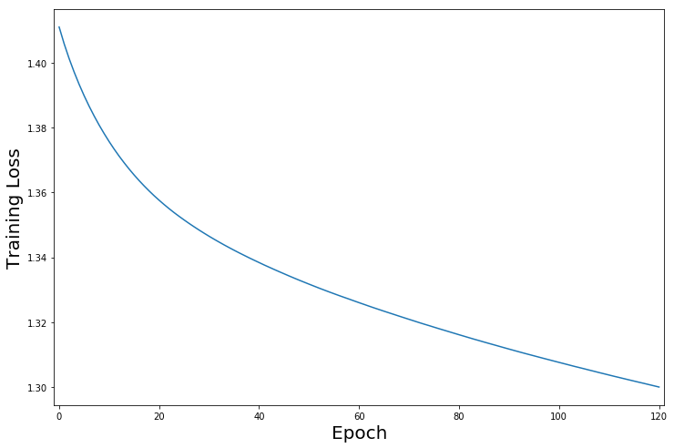

```
Accuracy of the network on the test set: 45.665 %
```

```python
NeuralNet_function(X_train_nn, y_train_nn, X_test_nn, y_test_nn,
                   input_size, hidden_size, num_classes, num_epochs, 256, learning_rate)
```

Now this gives better performance but a poor convegence of 1.31 compared to 1.24 initially ATOW.

The explaination to this is that a smaller batch size has been shown to make the model not reach the global optima, but rather ocilate around it. It also prevents the model from overfitting the trainin set which leads to poor accuracy on the test set.

On the other hand, a large batch size guarantees the model to reach the global optima and the run time is a lot faster as it used larger RAM space but the convergence is slower.

### 3.3

```python
def NeuralNet_dropout(X_train_nn, y_train_nn, X_test_nn, y_test_nn,
                      input_size, hidden_size, num_classes,num_epochs, batch_size, learning_rate, details, p):

    # Below is the same code as the previous function but with added dropout
    train_nn = torch.utils.data.TensorDataset(X_train_nn, y_train_nn)
    train_loader = torch.utils.data.DataLoader(train_nn, batch_size=batch_size)

    test = torch.utils.data.TensorDataset(X_test_nn, y_test_nn)
    test_loader = torch.utils.data.DataLoader(test, batch_size=batch_size)

    class NeuralNet(nn.Module):
        def __init__(self, input_size, hidden_size, num_classes):
            super(NeuralNet, self).__init__()
            self.fc1 = nn.Linear(input_size, hidden_size)
            self.fc2 = nn.Linear(hidden_size, hidden_size)
            self.fc3 = nn.Linear(hidden_size, num_classes)
            ###############
            # ADD DROP OUT#
            ###############
            self.dropout = nn.Dropout(p)

        def forward(self, x):
            out = F.relu(self.fc1(x))
            out = F.relu(self.fc2(out))
            out = self.fc3(out)

            return out

    net = NeuralNet(input_size, hidden_size, num_classes)

    criterion = nn.CrossEntropyLoss()

    optimiser = torch.optim.SGD(net.parameters(), lr=learning_rate)

    total_step = len(train_loader)
    loss_values = []

    start_time = time.time()
    for epoch in range(num_epochs+1):

      #TRAIN
      net.train()
      train_loss = 0.0

      for i, (inputs, labels) in enumerate(train_loader, 0):

        labels = labels
        outputs = net(inputs)
        loss = criterion(outputs, labels)

        optimiser.zero_grad()
        loss.backward()
        optimiser.step()

        train_loss += loss.item()

      loss_values.append(train_loss / total_step)

    if details == 'yes':
        print('Finished Training')
        elapsed_time = int(time.time() - start_time)
        print('Time it took to train model: {:02d}min {:02d}sec'.format((elapsed_time % 3600 // 60), elapsed_time % 60))

        plt.figure(figsize=(12,8))
        plt.xlim(-1, num_epochs+1)
        plt.ylabel('Training Loss', fontsize=20)
        plt.xlabel('Epoch', fontsize=20)
        plt.plot(loss_values)

        plt.show()

    #TEST
    net.eval()

    correct = 0
    total = 0

    y_predNN = []
    for inputs, labels in test_loader:
      outputs = net(inputs)
      _, predicted = torch.max(outputs.data, 1)
      y_predNN.append(predicted.numpy())
      total += labels.size(0)
      correct += (predicted == labels).sum().item()

    y_predNN = np.concatenate(y_predNN)
    accuracy = 100 * correct / total

    if details == 'yes':
        print('Accuracy of the network on the test set: {0:.3f} %'.format(accuracy))

    return y_predNN, accuracy
```

You'll notice that this time I'm making this neural network not to automatically show time elapsed, the convergence plot or the accuracy because I don't want these to appear when I do my cross validation (they would end up appearing 5 times the amount of hyperparameter values I'm testing).

Now we want to tune that parameter p using stratified 5 fold cross validation. I can't use GridSeacrhCV again as my neural network function isn't a predefined model so I create my own cross validation function instead.

```python
def NN_crossval(X_train, y_train, p_values):

    #Define set-up of neural network
    input_size = 6
    hidden_size = 200
    num_classes = 4
    num_epochs = 120
    batch_size = 64
    learning_rate = 0.01

    #Length of vector of values of p to test, so I know the amount of loops I will need to perform
    total_p = len(p_values)

    #Define cross validation method
    skf = StratifiedKFold(n_splits=5, shuffle = True, random_state = 999)

    #Define empty tables that I will later fill with scores
    accuracy_validation = np.zeros([total_p,5])
    mean_validation_score = pd.DataFrame([0]* total_p, columns = ['mean validation score'])
    label = [0] * total_p

    # Labelling table
    for i in range(total_p):
        label[i] = str(p_values[i])
    mean_validation_score.index = label


    j = 0

    #Start folds
    for train_index, test_index in skf.split(X_train, y_train):

        #Convert data to tensors for neural network
        X_train_nn = torch.from_numpy(X_train.iloc[train_index].values).float()
        y_train_nn = torch.from_numpy(np.array(y_train.iloc[train_index]))
        X_test_nn = torch.from_numpy(X_train.iloc[test_index].values).float()
        y_test_nn = torch.from_numpy(np.array(y_train.iloc[test_index]))

        #Apply network for each value of p
        for i in range(total_p):
            p = p_values[i]

            y_pred, accuracy_validation[i,j] = NeuralNet_dropout(X_train_nn, y_train_nn, X_test_nn, y_test_nn,
                                              input_size, hidden_size, num_classes, num_epochs, batch_size, learning_rate, 'no', p)

        #Define mean validation accuracy over the 5 folds for each value of p
        mean_validation_score.iloc[j,0] = np.mean(accuracy_validation[:,j])

        j = j+1

    #Return table of p values and their mean validation accuracy
    return mean_validation_score
```

Now that my cross validation algorithm is created, I tune the value p:

```python
p_values = np.arange(0, 1, 0.2)
NN_crossval(X_train, y_train, p_values)
```

|  | mean validation score |
| --- | --- |
| 0.0 | 33.685714 |
| 0.2 | 35.862069 |
| 0.4 | 33.735632 |
| 0.6000000000000001 | 34.913793 |
| 0.8 | 33.821839 |

```
Finished Training
Time it took to train model: 00min 23sec
```

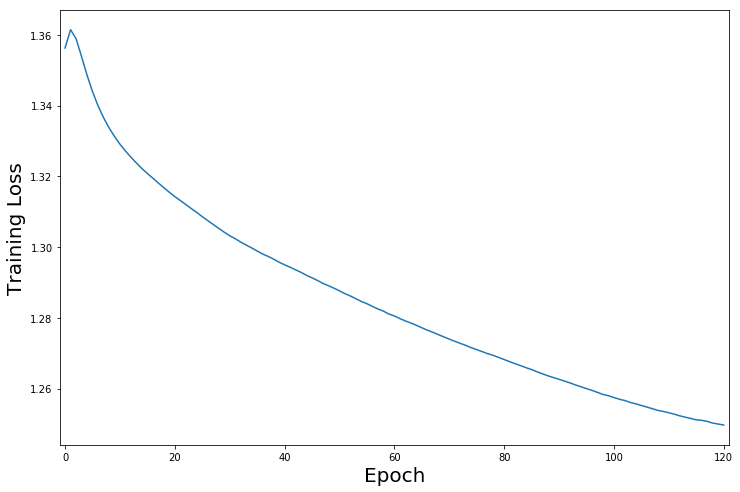

```
Accuracy of the network on the test set: 42.540 %
```

```python
y_predNN, accuracyNN = NeuralNet_dropout(X_train_nn, y_train_nn, X_test_nn, y_test_nn,
                      input_size, hidden_size, num_classes,num_epochs, batch_size, learning_rate, 'yes', p=0.4)
```

## Task 4

For this final task, let us compare the performance of our three models.

### 4.1

Let us the classification report, confusion and accuracy on test set of each model.

```
RANDOM FOREST CLASSIFIER

              precision    recall  f1-score   support

           0       0.90      0.64      0.75       412
           1       0.35      0.38      0.36       188
           2       0.31      0.34      0.32       204
           3       0.39      0.55      0.45       188

   micro avg       0.51      0.51      0.51       992
   macro avg       0.49      0.48      0.47       992
weighted avg       0.58      0.51      0.53       992

Confusion matrix
```

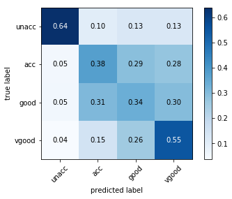

```
Accuracy of optimised RFC's prediction on the test set: 51.210%
Run time ATOW: 18 min


-------------


SUPPORT VECTOR MACHINE

              precision    recall  f1-score   support

           0       0.85      0.64      0.73       412
           1       0.36      0.49      0.42       188
           2       0.47      0.30      0.37       204
           3       0.40      0.63      0.49       188

   micro avg       0.54      0.54      0.54       992
   macro avg       0.52      0.52      0.50       992
weighted avg       0.60      0.54      0.55       992

Confusion matrix
```

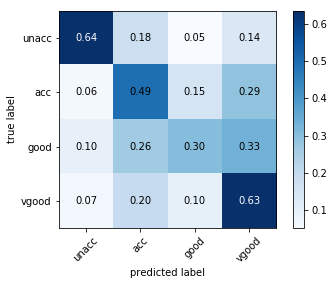

```
Accuracy of optimised SVM's prediction on the test set: 54.032%
Run time ATOW: 6 min


-------------


NEURAL NETWORK WITH DROP OUT

              precision    recall  f1-score   support

           0       0.97      0.53      0.68       412
           1       0.50      0.06      0.10       188
           2       0.23      0.09      0.13       204
           3       0.26      0.93      0.41       188

   micro avg       0.43      0.43      0.43       992
   macro avg       0.49      0.40      0.33       992
weighted avg       0.59      0.43      0.41       992

Confusion matrix
```

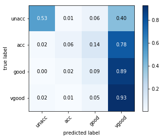

```
Accuracy of optimised NN's prediction on the test set: 42.540%
Run time ATOW: 22 sec
```

```python
from sklearn.metrics import confusion_matrix
from sklearn.metrics import classification_report
from mlxtend.plotting import plot_confusion_matrix

class_names = ['unacc', 'acc', 'good', 'vgood']
print('RANDOM FOREST CLASSIFIER')
print()
print(classification_report(y_test, y_predF))
print('Confusion matrix')
fig, ax = plot_confusion_matrix(conf_mat=confusion_matrix(y_test, y_predF),
                                colorbar=True,
                                show_absolute=False,
                                show_normed=True,
                                class_names=class_names)
plt.show()
print("Accuracy of optimised RFC's prediction on the test set: {0:.3f}%"
      .format( 100* accuracy_score(y_test, y_predF)))
print('Run time ATOW: 18 min')
print()
print()
print('-------------')

print()
print()
print('SUPPORT VECTOR MACHINE')
print()
print(classification_report(y_test, y_predSVM))
print('Confusion matrix')
fig, ax = plot_confusion_matrix(conf_mat=confusion_matrix(y_test, y_predSVM),
                                colorbar=True,
                                show_absolute=False,
                                show_normed=True,
                                class_names=class_names)
plt.show()
print("Accuracy of optimised SVM's prediction on the test set: {0:.3f}%"
      .format( 100* accuracy_score(y_test, y_predSVM)))
print('Run time ATOW: 6 min')
print()
print()
print('-------------')
print()
print()
print('NEURAL NETWORK WITH DROP OUT')
print()
print(classification_report(y_test, y_predNN))
print('Confusion matrix')
fig, ax = plot_confusion_matrix(conf_mat=confusion_matrix(y_test, y_predNN),
                                colorbar=True,
                                show_absolute=False,
                                show_normed=True,
                                class_names=class_names)
plt.show()
print("Accuracy of optimised NN's prediction on the test set: {0:.3f}%"
      .format(accuracyNN))
print('Run time ATOW: 22 sec')
```

### 4.2

Let me summarise all this information:

*Best precision*: SVM

*Best recall*: SVM

*Best F1-score*: SVM

*Best confusion matrix overall*: SVM (we look at the matrix that has the deepest coloured diagonal overall)

*Best test accuracy*: SVM

*Lowest computational cost (shortest time)*: NN

From these information, the support vector machine seems to be the most approprate choice for rating the task. It makes sense considering my computational facilities I have since NN needs much more resources in comparison to SVM, especially deep learning algorithms. SVM is more reasonable in that sense. Althought the Neural network took far less time than the other two models, it cost the overall performance on the test set as we don't yied to a good prediction of the test set. Random Forest seems to be a good middle ground in that aspect.